# Exploratory data analysis for hourly time series

```python
import pandas as pd
import numpy as np

from statsmodels.graphics.tsaplots import plot_acf, plot_pacf
from statsmodels.tsa.seasonal import seasonal_decompose,STL
from matplotlib import pyplot as plt, rc_context, rc
plt.style.use('seaborn-deep')
```

We start by reading the data

```python
ts = pd.read_csv("hourly_total.csv", parse_dates=['timestamp'], index_col=['timestamp'])
ts
```

| timestamp | kWh |
| --- | --- |
| 2017-01-01 00:00:00 | 7985.77 |
| 2017-01-01 01:00:00 | 7780.45 |
| 2017-01-01 02:00:00 | 7676.35 |
| 2017-01-01 03:00:00 | 7722.80 |
| 2017-01-01 04:00:00 | 7716.57 |
| ... | ... |
| 2019-12-31 20:00:00 | 11171.96 |
| 2019-12-31 21:00:00 | 10570.42 |
| 2019-12-31 22:00:00 | 10077.17 |
| 2019-12-31 23:00:00 | 9530.08 |
| 2020-01-01 00:00:00 | 9254.37 |

26281 rows × 1 columns

First, we look at some descriptive statistics about the data.

```python
ts.describe()
```

|  | kWh |
| --- | --- |
| count | 26281.000000 |
| mean | 12064.554405 |
| std | 4915.637292 |
| min | 5801.520000 |
| 25% | 8453.570000 |
| 50% | 10111.080000 |
| 75% | 14381.880000 |
| max | 26206.430000 |

Note that this data is on the hourly resolution; therefore, the max value is much lower than the average (or even the minimum) value of the daily data. Next, we try to visualize the time series to gain some insights.

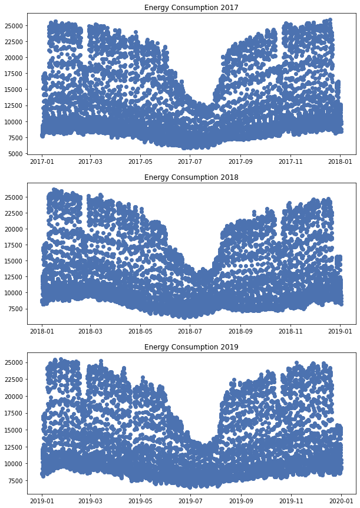

```python
ts2017,ts2018,ts2019 = ts['2017-01-01':'2018-01-01'],ts['2018-01-01':'2019-01-01'],ts['2019-01-01':'2020-01-01']
fig,ax =  plt.subplots(3,figsize=(10,15))

ax[0].plot(ts2017,'o')
ax[0].set_title('Energy Consumption 2017')
ax[1].plot(ts2018,'o')
ax[1].set_title('Energy Consumption 2018')
ax[2].plot(ts2019,'o')
ax[2].set_title('Energy Consumption 2019')

plt.show()
```

We could already identify some general patterns from the data above. For example, we notice that the demand peaks in winter-spring then bottoms out during summer. We should zoom in on different parts of the series.

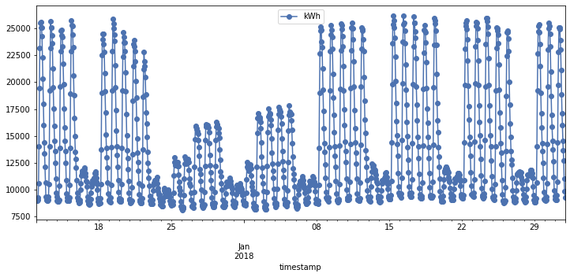

```python
def plot(data, start, end):
    data.loc[start:end].plot(figsize=(12,5), style='o-')
    plt.show()


plot(df, '2017-12-12', '2018-01-31')
```

It looks like that during the holidays (winter - new year), there is low electricity demand. In addition, during the weekend, the demand is lower than in the weekdays. Next, we investigate the summer months.

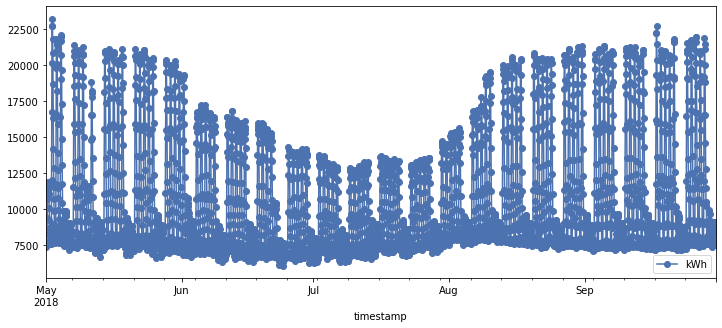

```python
plot(df, '2018-05-01', '2018-09-30')
```

Compared to the plot above, it is clear that the demand in the summer is lower than the other seasons. There is a decreasing trend in demand in the first half of the year, and there is an increasing trend in the second half of the year. This situation should be the same for 2017:

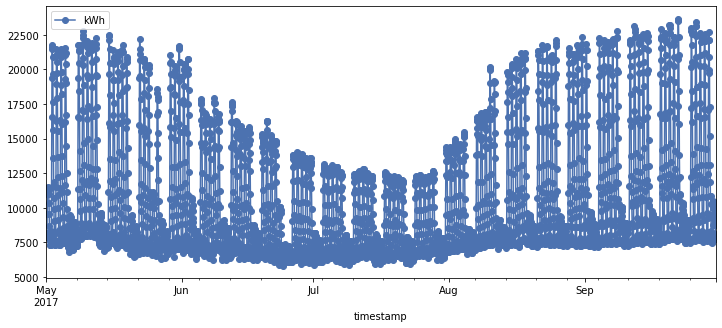

```python
plot(df, '2017-05-01', '2017-09-30')
```

Indeed it is. Next, we zoom in on a random week.

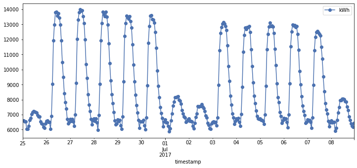

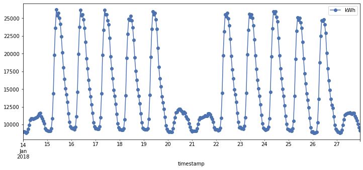

```python
plot(df, '2017-06-25', '2017-07-08')
plot(df, '2018-01-14', '2018-01-27')
```

The plot above further emphasizes the weekly trend as well as reveals the daily trends: the demand tend to peak locally at around noon (Finnish time). The trends and seasonalities above (except for the daily seasonality) are also explained in the Exploratory Data Analysis for daily data section.

Since this is a time series, we should look at its autocorrelation function plot to identify any patterns that could potentially help us build common models such as ARIMA.

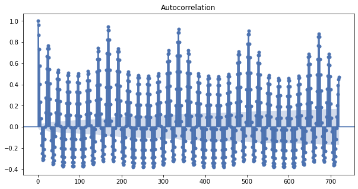

```python
with rc_context():
    rc("figure", figsize=(10,5))
    plot_acf(df['kWh'], lags=720) # 720 hours, or 30 days
    plt.show()
```

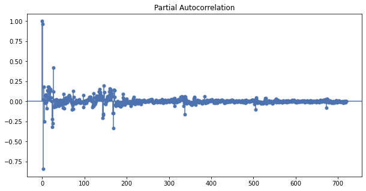

```python
with rc_context(): # takes quite some time to run
    rc("figure", figsize=(10,5))
    plot_pacf(df['kWh'], lags=720)
    plt.show()
```

As is identified above and further confirmed with these two plots, this time series has multiple seasonality and complex seasonality patterns. For this kind of time series, ARIMA (a common time series model) will not work very well.

Here, we also try to decompose the time series with the `seasonal_decompose` method as well as the `STL` method. The period is $24\times 7$ hours because from most of the plots above (and from the previous EDA section on daily data), there is a weekly cycle, and there are $24\times 7$ hours in a week. Of course, there are other seasonalities in this data, but the period mentioned above should demonstrate well this decomposition.

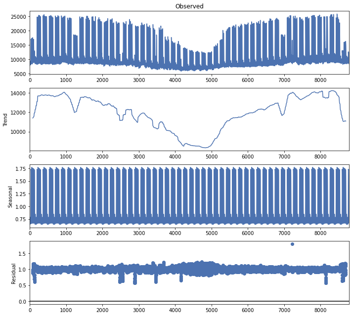

```python
decompose = seasonal_decompose(ts2017.values, period = 24*7, model="multiplicative")
plt.rcParams.update({'figure.figsize':(10,9)})
f = decompose.plot()
```

Here, residuals clearly resemble white noise, except for several locations (columns going down). Those locations are the holidays, which was not taken into account by the decomposition method. However, the multiplicative method works well enough, as these plots look similar to the ones below, which were created with the better STL method. Repeating the multiplicative decompostion formula for the sake of clarity:

$$ \begin{aligned} y_t=S_t\times T_t\times R_t \end{aligned} $$

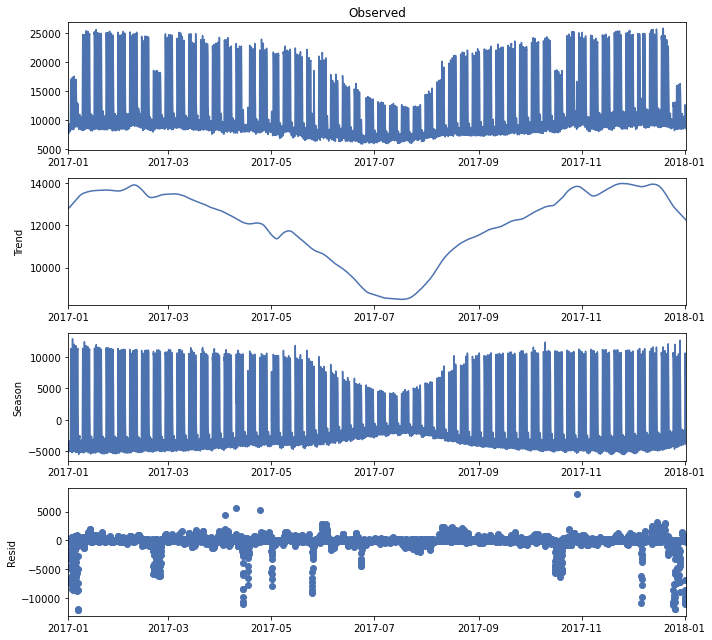

```python
stl = STL(ts2017,period=24*7,robust=True)
res = stl.fit()
fig = res.plot()
```

Now, we are pretty confident that the hourly electricity demand time series consists of three main components: A (yearly) trend that reaches bottom in July, a complex seasonality component, and holiday effects.